# Checking the Model, Seeing the Season

Module 5 · Residual diagnostics and seasonality

Gary Cornwall

Econ 6376 · The George Washington University

## Where we are: the last knob on the board

$$y_t=\alpha+\delta t+\sum_{j=1}^{p}\phi_j y_{t-j}+\sum_{l=1}^{q}\theta_l\epsilon_{t-l}+\epsilon_t$$

| Term | L3 | L4 | **L5** |
| --- | --- | --- | --- |
| $\alpha$, $\delta t$ | on | on | on |
| $\phi_j y_{t-j}$, all $p$ | on | on | on |
| $\theta_l \epsilon_{t-l}$, all $q$ | on | on | on |
| **Seasonal block** — the same structure at lag $s$ | off | off | turning on today |
| $\epsilon_t$ | on | on | on |

Two halves, one picture. **Part A**: learn to *check* a model — residuals are the final jury. **Part B**: the structure Module 4’s residuals kept pointing at — what seasonality is, and three ways to treat it.

By the end of today every slider on the mixing board is on.

## Last time ended on a spike. Reproduce it.

```r
library(forecast)
csv <- read.csv("../../data/UNRATE.csv")   # cached FRED pull
csv <- subset(csv, observation_date >= "1960-01-01" &
                   observation_date <= "2019-12-01")
unrate   <- ts(csv$UNRATE, start = c(1960, 1), frequency = 12)
d_unrate <- diff(unrate)

fit_l4 <- Arima(d_unrate, order = c(1, 0, 2),   # Module 4's pick,
                include.mean = FALSE)   # same zero-mean policy
e_hat  <- residuals(fit_l4)
ggAcf(e_hat, lag.max = 36)
acf(e_hat, lag.max = 36, plot = FALSE)$acf[c(13, 25, 37)]
```

$\hat\rho_e(12)$−0.145

$\hat\rho_e(24)$−0.125

$\hat\rho_e(36)$−0.130

band, $1.96/\sqrt{T}$ (≈ $2/\sqrt{T}$)±0.073

Same window as Module 4: 1960-01 to 2019-12, $T = 719$ differences. The low lags are quiet. The spikes every twelve months survive.

What would you need to see to sign off on this model?

## Cached: the Module 4 residual ACF

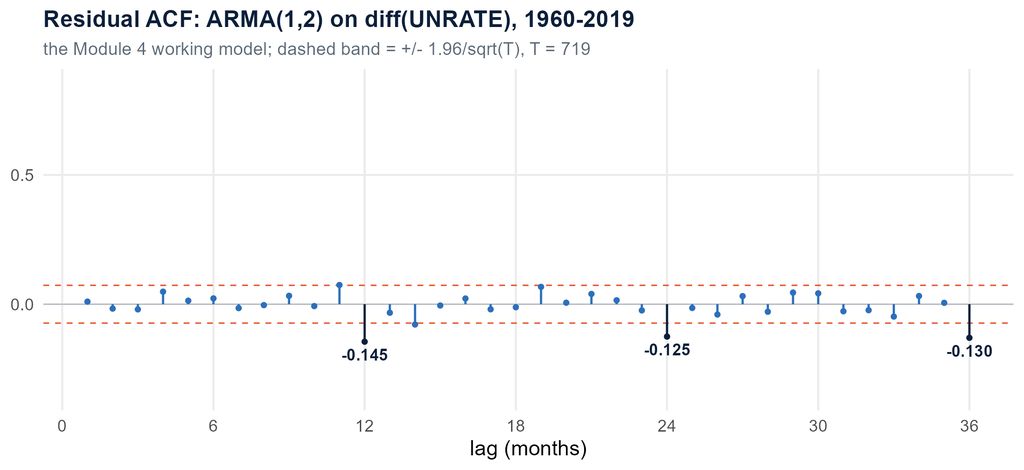

## The principle: residuals should behave like innovations

- $\epsilon_t$ is the **innovation** — the DGP’s shock. Unobserved.
- $e_t = y_t - \hat y_t$ is the **residual** — what the fitted model leaves. Observed.
- If the model is right, $e_t$ should *behave like* $\epsilon_t \sim \text{WN}(0,\sigma^2)$. Not *is* white noise — no finite sample is — but *could plausibly be*.
- If it does not, there is nothing to fix in the data. There is something to fix in the model.

**Four checks, one ranked line:**

serial correlation → heteroskedasticity → zero mean → normality

The first is the whole of today. The second is a preview of Module 14 — eyeball it for now. The last two are cheap, and almost never the real problem.

## Serial correlation: the definition, then the rule

| Term | Meaning | Belongs to |
| --- | --- | --- |
| **Autocorrelation** (dependence, memory, persistence) | A property of a series, measured by its ACF — any series, residuals included | the **data** |
| **Serial correlation** | The diagnostic verdict that a fitted model’s residuals $e_t$ show autocorrelation | the **model**, relative to the data |
| **Residual seasonality** | Seasonal autocorrelation left in a published seasonally adjusted series | the **adjustment procedure** — itself a model |

> *“Serial correlation is not a property of the data — it is a property of your model relative to the data. It means your model is wrong.”*

Enders, Hamilton, and Hyndman & Athanasopoulos use *autocorrelation* and *serial correlation* interchangeably, and so does most applied practice. Recognize that usage in the wild; the course’s line is deliberate.

[figure not shown]

[figure not shown]

Neither is a property of the data.

## Reading residuals against the Module 3 table

| Residual ACF pattern | First candidate diagnosis — a proposal, not a verdict |
| --- | --- |
| Mostly inside $\pm 2/\sqrt{T}$, no systematic pattern | no visible evidence of remaining serial correlation |
| Spike at lag 1 only | an omitted short-run AR or MA term |
| Geometric decay from lag 1 | omitted low-order AR dynamics |
| Cutoff after a few lags | omitted low-order MA dynamics |
| **Spikes at $s, 2s, 3s$** (here $12, 24, 36$) | omitted dependence at the seasonal frequency — **today’s transition** |
| Large correlations that persist, not decay | insufficient differencing; reassess the transformation |

Same table as Module 3, different question: there it told you what to *fit*; here, what your fit *missed*. Propose the next candidate, refit, re-check — a diagnosis earns its place only if the revised fit removes the pattern without creating a new one.

## Misspecify and watch: predict the residual ACF before every move

Pick a DGP you know — AR(2), MA(2), or the two glued together — fit an ARMA($p,q$), read the residual ACF and the Ljung-Box verdict. Predict before every move.

[interactive chart not shown]

## Three lessons from the simulation

1. **The diagnostic tools work.** When the residuals carry real structure, Ljung-Box flags it without knowing the DGP, and the residual ACF shape proposes what to add — a candidate, not a verdict.
2. **The fit will not volunteer the problem.** Fit the one-block-short model with `Arima()` and it prints coefficients, standard errors, an AIC, a log-likelihood. None of them says “short”. Stop at the IC winner without checking residuals and you own a confidently wrong model. Module 1’s spurious-regression Monte Carlo, in a new setting: the printout lies, and only a dependence-aware check catches it.
3. **The structure came from the model.** The DGP was perfectly well behaved. The serial correlation in the residuals was *generated by the fit*. The correct orders leave white noise — and extra orders leave white noise too, at a price diagnostics cannot see and only parsimony can. Change the fit and the structure is gone; the data never moved.

Serial correlation is a model report card, not a disease the data has.

## Ljung-Box, on one slide

$$Q(h)=T(T+2)\sum_{k=1}^{h}\frac{\hat\rho_k^{\,2}}{T-k}
\;\stackrel{a}{\sim}\;\chi^2_{\,h-\text{fitdf}}$$

- $\hat\rho_k$ is the sample autocorrelation of the **residuals** at lag $k$; a joint test that the first $h$ of them are all zero.
- **fitdf** $= p+q$ for a non-seasonal ARMA fit, $p+q+P+Q_s$ for a SARIMA fit, $0$ for a raw series with no model. You spent those degrees of freedom estimating; the test charges for them.
- **Choose $h$ before you look**: $h=10$ for non-seasonal residuals, $h=24$ for monthly seasonal residuals. Report both on monthly data. Hunting across $h$ until one rejects is $p$-hacking with a chi-square.
- **Large $p$-value is good news.** In regression you want to reject. In diagnostics you want to *fail* to reject: no structure found.

```r
Box.test(e_hat, lag = 10, type = "Ljung-Box", fitdf = 3)   # p + q = 1 + 2
Box.test(e_hat, lag = 24, type = "Ljung-Box", fitdf = 3)
checkresiduals(fit_l4)                                     # the all-in-one from forecast
```

## Verdict on the Module 4 fit

```r
Box.test(e_hat, lag = 10, type = "Ljung-Box", fitdf = 3)
Box.test(e_hat, lag = 24, type = "Ljung-Box", fitdf = 3)
checkresiduals(fit_l4)
```

$h=10$: $Q = 3.76$, $\chi^2_{7}$p = 0.807 · pass

$h=24$: $Q = 46.1$, $\chi^2_{21}$p = 0.0012 · fail

The two horizons disagree, and the disagreement is the lesson. Over ten lags these residuals are white noise. Widen the window to lag 24 and the joint statistic sees what the eye saw: a test that never looks at lag 12 cannot reject because of lag 12.

The residual ACF shows no decay from lag 1, no cutoff, no spike at lag 1 — the Module 3 table’s first four rows are empty.

What it shows is spikes at 12, 24, 36. Every twelve months. Same sign each time.

Spikes that recur at regular intervals. What are those?

## Cached: `checkresiduals()` on the Module 4 fit

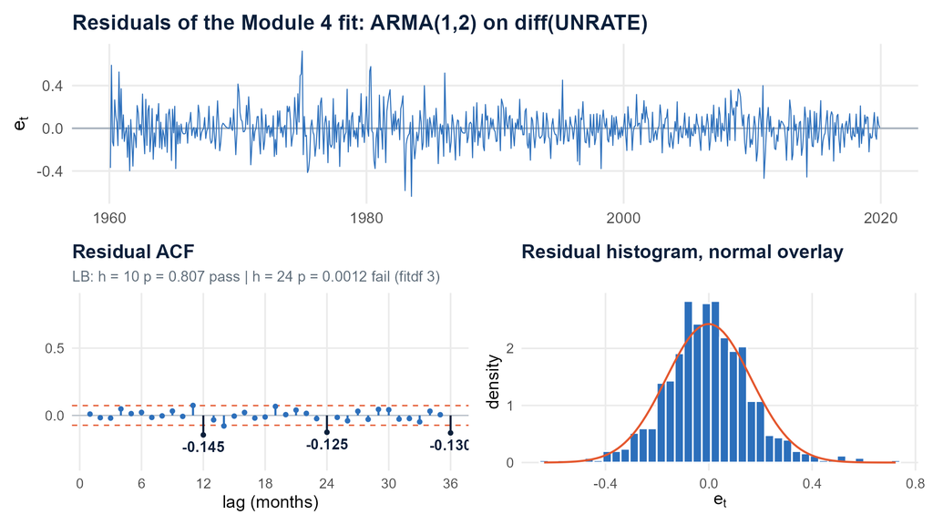

## You can see it

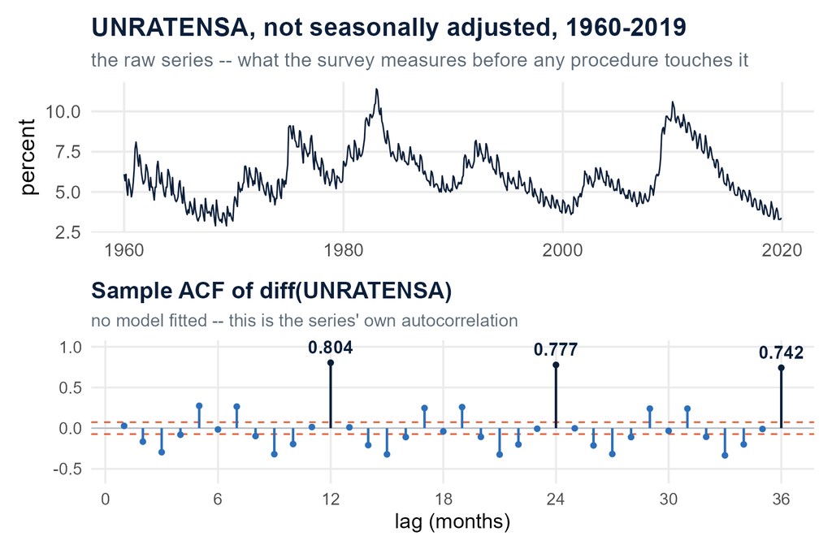

**UNRATENSA** — the same civilian unemployment rate, *not* seasonally adjusted. What the survey measures each month.

$\hat\rho(12)$ of $\Delta$UNRATENSA0.804

$\hat\rho(24)$0.777

$\hat\rho(36)$0.742

band±0.073

$\hat\rho(12)$ of $\Delta$UNRATE, published−0.089

**No model has been fitted.** This is the series’ own **autocorrelation**. The lag-12 spike in the Module 4 residuals was **serial correlation** — a verdict on a fit. Same picture, different owner.

Ten times the band, and barely decaying from one year to the next. Hold that thought.

## Nobody agrees what it is — but you can see it

| Tradition | Core object | Representative work |
| --- | --- | --- |
| **Calendar means** (regularity and repetition) | Seasonal means across a calendar partition | Falkner (1924); Kallek (1978) |
| **Seasonal unit roots and stability** (the ARIMA polynomial) | Roots of the AR polynomial at the seasonal frequencies | Hylleberg, Engle, Granger & Yoo (1990); Canova & Hansen (1995) |
| **Unobserved components** (signal extraction) | A latent seasonal component $S_t$ identified by a restriction | Hillmer & Tiao (1982); Bell & Hillmer (1984); X-13ARIMA-SEATS |
| **Spectral** (frequency domain) | A functional of the spectral density at the seasonal frequencies | Nerlove (1964); Granger (1978) |

Each is internally consistent and answers a well-posed question. **None nests the others.** Analysts consult several at once and quietly assemble a superset nobody has written down.

> *“Some of us looking for answers regarding seasonal analysis may feel as if we’re in a dark room looking for a black cat. That’s bad, but it’s not as bad as it could be. Pity the philosophers who are in a dark room looking for a black cat that isn’t there.”* — Zellner et al. (1978, p. 451)

## There is no clean “isn’t”

Students want a checklist: seasonality is X; calendar effects, trading days, holidays are *not* seasonality. The course declines, and the reason matters.

- **A definition is a line you draw.** Choose one — seasonal means, seasonal unit roots, a latent component, a spectral peak — and whatever lands inside that line is seasonal *by construction*, whether or not you would have called it that beforehand.
- **Trading-day variation** is the standard case: the number of Mondays in a month varies with a rhythm close to, but not at, the annual frequency. Under a spectral definition it leaks into the seasonal frequencies; under a calendar-means definition it lands in the monthly means. The definition decides, and different definitions decide differently. Moving holidays likewise.
- These effects are **not statistically separable** from seasonality without an extra identifying assumption — which is exactly what X-13 supplies when it pre-regresses them out.
- **The one safe non-example:** monthly sampling alone does not make a series seasonal. A random walk observed every month has a seasonal *frequency* at which structure could live. It does not put structure there.

Hold on to “the line you draw”. The Deeper Dive at the end of today draws one explicitly — a partition of the frequency axis — and then asks a testable question relative to it.

## The triage: three paths

| Diagnosis or need | Path | What it commits you to |
| --- | --- | --- |
| The pattern is **deterministic** — fixed, exogenous, calendar-driven | **Path 1 · seasonal dummies** (or Fourier terms) in a regression | a fixed shape; if the pattern drifts, the residuals will say so |
| The pattern is **stochastic** — it drifts, and you want to *model* it and forecast with it | **Path 2 · SARIMA** — seasonal ARMA terms, with seasonal differencing if there is a seasonal unit root | a joint model of both bands of the console |
| “I need it **gone, not modeled**” — a series you can read, compare month to month, or feed to a non-seasonal model | **Path 3 · seasonal adjustment** — decompose, remove the seasonal, publish the rest | trusting a procedure that is itself a model |

The three are not rivals. Agencies run path 3 to publish the series you read in the news; forecasters run path 2 on the raw or the published series; path 1 is the cheap first question — *is the pattern fixed?*

A journalist comparing this month to last month — which path? A forecaster building next year’s fan chart?

All three, next, on one series: the raw unemployment rate.

## Path 1: seasonal dummies

On the **first difference** — the course has treated the unemployment rate as $I(1)$ since Module 2 — regress on eleven month indicators plus an intercept, with month index $m$ and January ($m=1$) as the reference:

$$\Delta y_t=\alpha+\sum_{m=2}^{12}\beta_m\,\mathbb{1}\{\text{month}_t=m\}+\epsilon_t$$

- **What it assumes:** a *fixed* monthly pattern. The same January jump in 1965 and in 2019. Eleven parameters $\beta_2,\ldots,\beta_{12}$, any shape. (The indicator is written $\mathbb{1}\{\cdot\}$ on purpose: $D$ is today’s seasonal differencing order, and $j$ is the AR lag index.)
- **What the residuals will tell you:** if the pattern really is fixed, the residual ACF is clean at 12, 24, 36. If it drifts, the seasonal spikes survive — and that verdict sends you to path 2.
- **The parsimonious cousin, one line:** replace the eleven dummies with a few sine–cosine pairs from `forecast::fourier()`. Fewer parameters, same fixedness — and fixedness, not parsimony, is what is about to be tested.

```r
seasonal_dummies <- function(y, ref = 1) { ... }     # helpers/seasonality.R: the (s - 1) indicator columns
```

## Path 1, live: fit the dummies, read the residuals

```r
nsa <- read.csv("../../data/UNRATENSA.csv")
nsa <- subset(nsa, observation_date >= "1960-01-01" &
                   observation_date <= "2019-12-01")
unratensa   <- ts(nsa$UNRATENSA, start = c(1960, 1),
                  frequency = 12)
d_unratensa <- diff(unratensa)

source("../../helpers/seasonality.R")   # seasonal_dummies()
X_month <- seasonal_dummies(d_unratensa)   # Jan = reference
fit_dum <- lm(d_unratensa ~ X_month)
summary(fit_dum)$r.squared                 # 0.72
e_dum <- ts(residuals(fit_dum), frequency = 12,
            start = start(d_unratensa))
ggAcf(e_dum, lag.max = 36)
Box.test(e_dum, lag = 24, type = "Ljung-Box", fitdf = 0)
```

Before the plot: the dummies absorb $R^2 = 0.72$. Will lag 12 clear the band?

residual $\hat\rho_e(12)$0.350

residual $\hat\rho_e(24)$0.298

residual $\hat\rho_e(36)$0.223

band±0.073

**Honestly:** the fitdf $=0$ Ljung-Box also rejects for non-seasonal reasons — lags 2, 3, 5, 7, 11 breach too, the Module 4 dynamics a dummy regression cannot carry. Give it ARMA(1,2) errors and only the seasonal lags do the rejecting: $h=10$ passes ($p=0.30$), $h=24$ fails.

**Is the pattern fixed?** Month effects by half, 1960–89 against 1990–2019: $F(11,695)=12.5$, $p\approx10^{-21}$. June halves ($+0.84\to+0.43$); July flips sign ($-0.33\to+0.02$).

The fixed part is absorbed. A drifting part remains. On to path 2.

## Cached: the dummy residuals

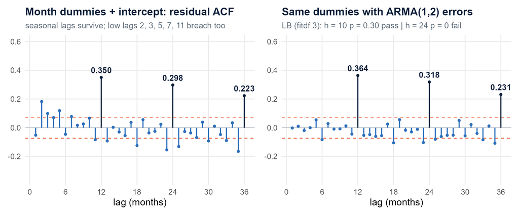

## Cached: the fitted monthly pattern, by half of the window

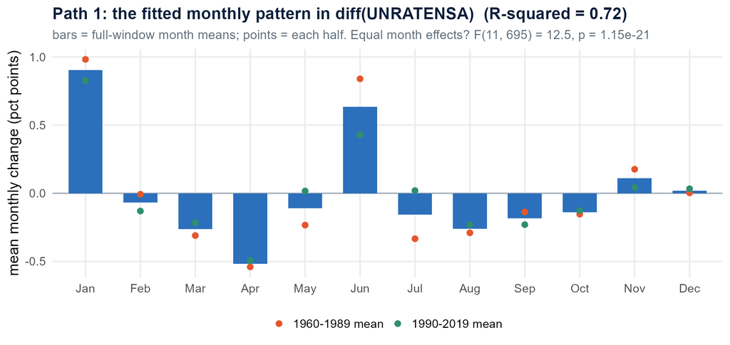

## Path 2: the seasonal band on the console

The non-seasonal band works at lags $1, 2, 3, \ldots$ — the knobs since Module 3. A seasonal process has a **second band** at lags $s, 2s, 3s, \ldots$ with the same kinds of knobs: AR, MA, and differencing.

$$\Phi_p(L)\,\Phi_P(L^s)\,(1-L)^d\,(1-L^s)^D\,y_t=\Theta_q(L)\,\Theta_Q(L^s)\,\epsilon_t$$

$$\Phi_p(L)=1-\phi_1L-\cdots-\phi_pL^p$$

$$\Phi_P(L^s)=1-\Phi_1L^s-\cdots-\Phi_PL^{Ps}$$

$$\Theta_q(L)=1+\theta_1L+\cdots+\theta_qL^q$$

$$\Theta_Q(L^s)=1+\Theta_1L^s+\cdots+\Theta_QL^{Qs}$$

- **Lowercase** $(p,d,q)$, $\phi$, $\theta$: the base band. **Uppercase** $(P,D,Q)$, $\Phi$, $\Theta$: the seasonal band. Minus signs on AR, plus signs on MA, in both bands.
- $s$ is the **period**: 12 monthly, 4 quarterly, 7 daily-with-a-weekly-cycle. ARIMA$(1,1,1)(0,1,1)_{12}$ reads: base band, seasonal band, monthly.
- $(1-L^s)^D$ is **seasonal differencing**, $\Delta_s y_t = y_t - y_{t-s}$ — the Module 2 operator at the seasonal frequency. New today.
- When the seasonal MA order appears alone in prose it is written $Q_s$, so it does not collide with the Ljung-Box $Q$.

## Multiplicative structure: lag 13 for free

The bands **multiply**. Take the smallest case with both on, ARIMA$(1,0,0)(1,0,0)_{12}$:

$$(1-\phi_1L)(1-\Phi_1L^{12})\,y_t=\epsilon_t$$

$$1-\phi_1L-\Phi_1L^{12}+\phi_1\Phi_1L^{13}$$

- Coefficients at lags 1, 12, and **13**. The lag-13 term is not a free parameter — it is the product $\phi_1\Phi_1$, forced by the multiplication.
- Lag-12 *and* lag-13 dynamics for **two parameters** instead of thirteen. That is what makes SARIMA parsimonious next to a long AR that reaches lag 12 by sheer depth.
- The cross-frequency dynamics come for free as products of low-order terms. If the residuals disagree with the product, a free lag-13 term (an additive seasonal) is the less restrictive alternative — but for most macro applications the product works.

`sarima_simulator()` in `helpers/simulators.R` does exactly this expansion before running the master-equation loop. (Worked in the notes’ Deeper Dive §5.7.2.)

## Reading the seasonal ACF: decaying or flat?

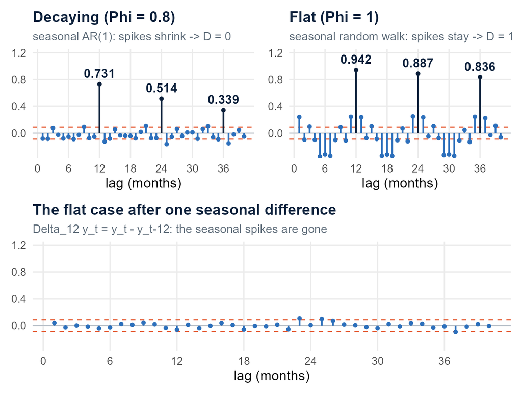

**Decaying** spikes at $s, 2s, 3s$: a stationary seasonal ARMA. Model the band, keep $D=0$.

**Flat** spikes near one: a seasonal unit root. Difference once at the seasonal frequency, $D=1$, then re-read.

Do not reach for $D=2$ without fresh evidence of a second seasonal unit root.

**The benchmark**, Box & Jenkins’s airline model, ARIMA$(0,1,1)(0,1,1)_{12}$:

$$(1-L)(1-L^{12})\,y_t=(1+\theta_1L)(1+\Theta_1L^{12})\,\epsilon_t$$

Two differences, two parameters. A benchmark to improve on, not an answer.

## Path 2, live: four candidates, one decision

```r
fit_air  <- Arima(unratensa, order = c(0, 1, 1), seasonal = list(order = c(0, 1, 1), period = 12))
fit_d0   <- Arima(unratensa, order = c(1, 1, 2), seasonal = list(order = c(1, 0, 1), period = 12))
fit_auto <- auto.arima(unratensa)
fit_win  <- Arima(unratensa, order = c(1, 1, 2), seasonal = list(order = c(0, 1, 1), period = 12))
source("../../helpers/diagnostics.R")   # lb_both()
lb_both(fit_win); checkresiduals(fit_win)
```

Before the table: which of the four will put a coefficient on a boundary?

| Candidate | Seasonal coefficient | LB $p$ (10 / 24) | Verdict |
| --- | --- | --- | --- |
| **Airline** $(0,1,1)(0,1,1)_{12}$ | $\hat\Theta_1=-0.78$, interior | $10^{-13}$ / $10^{-11}$ | **fails both**: the $(0,1,1)$ block is too thin — residual ACF 0.21, 0.14, 0.12, 0.11 at lags 2–5 |
| **$D=0$** $(1,1,2)(1,0,1)_{12}$ | $\hat\Phi_1=\mathbf{0.994}$ | 0.97 / 0.76 | passes and wins the $D=0$ table, but the seasonal AR root, in $z=L^{12}$, has modulus 1.006, within 0.01 of the unit circle: **a seasonal unit root in disguise** |
| `auto.arima()` $(2,0,2)(2,1,2)_{12}$ | $d=0$, $D=1$, eight coefficients | 0.27 / 0.47 | passes; a third differencing class, so its AICc is on neither table — a very good intern, read its work |
| **Winner** $(1,1,2)(0,1,1)_{12}$ | $\hat\Theta_1=-0.75$, interior | 0.88 / 0.42 | passes both horizons, every coefficient interior, same differencing as the airline |

## Information criteria compare only within a differencing class

A $D=1$ likelihood is evaluated on the seasonally differenced series — a different, shorter series than a $D=0$ model uses — and $d=0$ is different again. The four candidates fall into **three classes**, and rows are comparable only within a class.

**The $(d,D)=(1,1)$ class**, the airline model against the winner:

|  | AIC | BIC | LB $p$ (10 / 24) |
| --- | --- | --- | --- |
| airline $(0,1,1)(0,1,1)_{12}$ | −155.7 | −142.0 | $10^{-13}$ / $10^{-11}$ |
| **$(1,1,2)(0,1,1)_{12}$** | **−206.2** | **−183.4** | **0.88 / 0.42** |

The winner beats the airline by **50 AIC / 41 BIC** points — the whole gap is the non-seasonal block.

- In the **$(1,0)$ class** the seasonal ARMA(1,1) band wins by hundreds of points over Module 4’s bare block — and its winner is the model with $\hat\Phi_1=0.994$.
- `auto.arima()` sits alone in the **$(0,1)$ class**; its AICc is on neither table.

The tables cannot pick among candidates 2, 3, 4. Diagnostics and the coefficients do.

And a check nobody planned: X-13’s own automatic model selection, run on the next path with no guidance, chose **the same orders** as the winner.

## Cached: the four residual ACFs

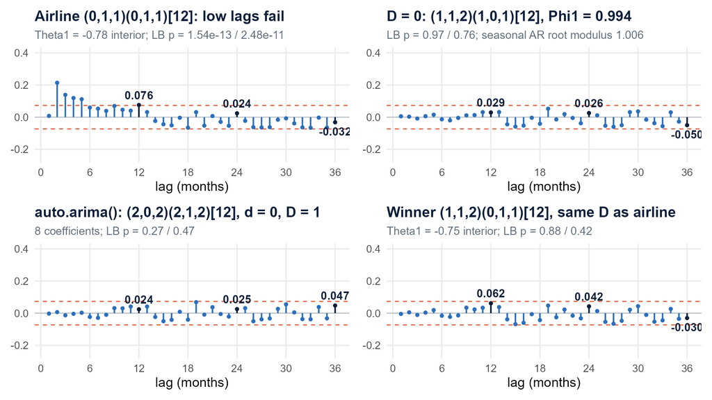

## $D$ is a commitment, and the data push back from both sides

### One seasonal difference too many

On the **published, already adjusted** UNRATE, impose $D=1$ — the airline model:

−0.99999

$\hat\Theta_1$, airline on UNRATE

The seasonal MA coefficient is pinned at the non-invertibility boundary: the Module 3 over-differencing signature. The model is trying to undo a difference the data did not need — the adjustment procedure had, in effect, already taken it.

### One seasonal difference too few

On the **raw** UNRATENSA, leave $D=0$ and model the band with seasonal ARMA terms:

+0.994

$\hat\Phi_1$, $(1,1,2)(1,0,1)_{12}$ on UNRATENSA

The seasonal AR coefficient is pinned at one — the root in $z=L^{12}$ has modulus 1.006, within 0.01 of the unit circle. The model is trying to manufacture a difference the data *did* need. Diagnostics pass; the coefficient tells the truth.

Either boundary estimate says: revisit $D$, not the ARMA orders.

Neither shows up in an IC table, because IC cannot compare across differencing orders — a $D=1$ likelihood is evaluated on a different, shorter series. When candidates disagree about differencing, decide on diagnostics and coefficients, and on out-of-sample forecasts (Module 6).

## Path 3: what seasonal adjustment does

A forecaster wants to *model* the seasonal band. A statistical agency, a journalist, a policymaker wants it *gone*, so this month can be compared with last month without the January jump in the way.

$$y_t=\text{trend-cycle}_t+\text{seasonal}_t+\text{irregular}_t$$

- **What it does.** Treat the series as three latent pieces (the unobserved-components tradition). Estimate the seasonal piece with a model. Subtract it. Publish the rest: trend-cycle plus irregular. The seasonal piece is *what the procedure decided was seasonal* — under its definition, with its identifying restriction.
- **Who does it.** The BLS, the Census Bureau, the BEA and their counterparts abroad run **X-13ARIMA-SEATS** (Census Bureau). It fits a regARIMA model — a SARIMA plus regressors for trading days, leap years, holidays and outliers — extends the series at both ends, and extracts the seasonal by X-11 filters or a SEATS model-based decomposition. Every option has a default; agencies tune them per series.
- **Why you must recognize it.** Most headline macro series you will ever download — the unemployment rate, payrolls, retail sales, GDP, CPI — are its outputs.

*Recognition level, deliberately: no simulate step, no spec file, one call.*

## Path 3, live: one call, and the reveal

```r
library(seasonal)            # wraps X-13ARIMA-SEATS
fit_x13 <- seas(unratensa)   # no options, no spec file
summary(fit_x13)             # chose (1 1 2)(0 1 1), SEATS,
                             # no log, leap year + weekday,
                             # and a level shift at 1975-01
sa_x13 <- final(fit_x13)
autoplot(cbind(published = unrate, x13 = sa_x13))
cor(sa_x13, unrate)
mean(abs(sa_x13 - unrate)); max(abs(sa_x13 - unrate))
```

Before the overlay: how close will one default call get to the published line?

correlation with published UNRATE0.9985

mean |difference|0.065 pp

max |difference| (1976-02)0.37 pp

months within 0.1 pp80%

The two adjusted lines are one line. The gaps are what a default call against a production run should leave — BLS adjusts concurrently, with its own span, regressors and revision history. One X-13 call **reproduces** the published series. Not *equals*.

The UNRATE series you have used since Module 2 is the output of this procedure.

Every ACF, ADF test, ARMA fit and information criterion in Modules 2–4 was computed on trend-cycle-plus-irregular from an X-13 run at the BLS, not on what the survey measured. Not a complaint — it changes what you are modeling.

## Cached: the overlay

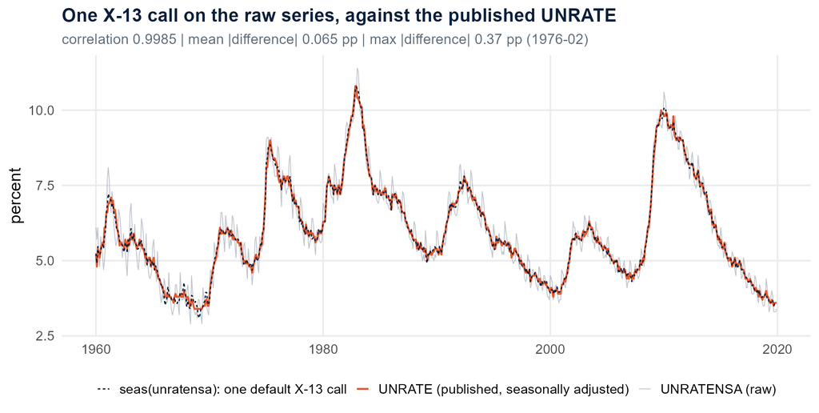

## The cost

**Adjustment is a model.** It fits a SARIMA, imposes an identifying restriction, and removes what that restriction calls seasonal. Like any model it can be wrong relative to the data — so the rule from Part A applies to it exactly as it applies to your own fits.

- The adjustment procedure can have **serial correlation of its own**. When it shows up at the seasonal lags of the published series, the course’s name for it is **residual seasonality** — seasonal autocorrelation left in a series that has already been adjusted.
- The published series carries the procedure’s choices as well as the data’s dynamics. A model fitted to it is partly modeling the procedure.
- The field’s tests and its filters answer different questions. A diagnostic from one tradition can flag seasonality that a filter built in another was never designed to remove — and the two do not speak the same language.

You cannot diagnose residual seasonality without saying what seasonality *is*.

A test for “seasonality left over” needs a definition to test against — the one thing the field has never agreed on. The Deeper Dive that follows is one way of drawing that line so it can be tested. It is optional and never assessed.

## Two representations of one series

Deeper Dive · not assessable

Every finite series $\{x_t\}_{t=1}^{T}$ has two equivalent descriptions, connected by the **discrete Fourier transform** at the Fourier frequencies $\omega_j = 2\pi j/T$:

$$d_x(\omega_j)=\sum_{t=1}^{T}x_t\,e^{-i\omega_j t}$$

$$x_t=\frac{1}{T}\sum_{j=0}^{T-1}d_x(\omega_j)\,e^{i\omega_j t}$$

- The **time domain** orders observations by calendar position — the language of every ACF and lag polynomial in this course.
- The **frequency domain** reallocates the *same* variance by **rate of repetition**: every two months, every six, every year, every decade.
- **Lossless.** The second formula recovers the series exactly.

*The series is a mixture. The DFT is the centrifuge that separates it into pure tones.* For monthly data the annual cycle lives at $\omega=\pi/6$, with **harmonics** at $\pi/3$, $\pi/2$, $2\pi/3$, $5\pi/6$, $\pi$.

[video not shown]

Time to frequency: the instructor’s animation, local file. Press play.

## The same seasonality in both domains

Deeper Dive · not assessable

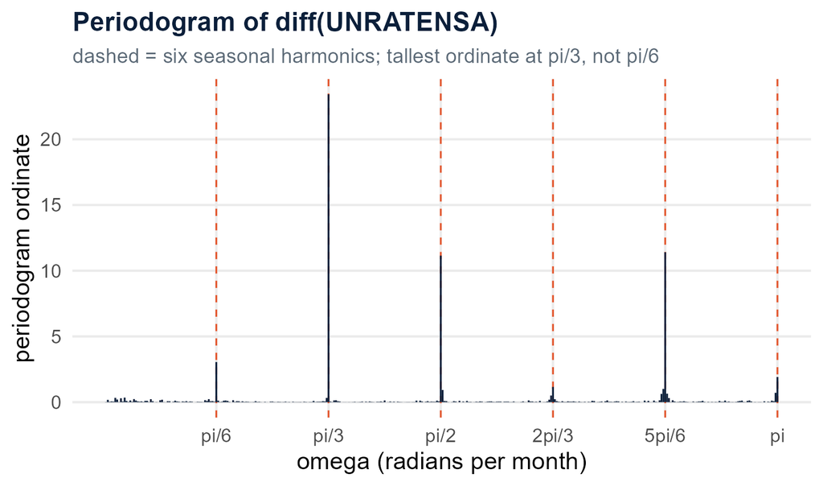

The **periodogram** $I_T(\omega_j)=\tfrac{1}{T}\lvert d_x(\omega_j)\rvert^2$ is the sample estimate of how variance is spread across frequencies.

Here it is for $\Delta$UNRATENSA — the series whose ACF spiked at 12, 24, 36. The spikes sit on the dashed lines: the same seasonality, by rate of repetition.

**Which line is tallest?** $\pi/3$ — the **semiannual** harmonic, a January jump and a June jump — not the annual $\pi/6$. The lag-12 spike cannot tell you that; the periodogram shows it at a glance.

Model-free: deterministic, stochastic and unit-root seasonality all show up the same way.

## A definition you can test

Deeper Dive · not assessable

Draw the line *before* looking at the data:

1. **Choose the cycles of interest.** Monthly data, annual period: the six harmonics $\Omega=\{\pi/6,\pi/3,\pi/2,2\pi/3,5\pi/6,\pi\}$.
2. **Partition** $(0,\pi]$ into $M$ equal-width bins $B_1,\ldots,B_M$. A bin is **seasonal** if it contains a harmonic; call that set $\mathcal M_1$, the rest $\mathcal M_0$.
3. **Compare the tallest peaks.** With $b_m(f)$ the highest value of the spectral density $f$ inside bin $m$,

$$\Delta(f)=\max_{m\in\mathcal M_1}b_m(f)\;-\;\max_{m\in\mathcal M_0}b_m(f)$$

A series is seasonal, relative to the chosen cycles and partition, if and only if $\Delta>0$.

In plain language: **the chosen cycles are demonstrably larger than every other cycle.** Relative, not absolute, so a narrow spike at $\pi/6$ and a diffuse hump around $\pi/3$ count alike, with no commitment to what generated the peak. Whatever lands in a seasonal bin counts, trading-day leakage included — the “no clean isn’t” made operational.

**One line on notation.** $\Delta$ has meant the difference operator since Module 1, $\Delta y_t = y_t - y_{t-1}$. This $\Delta$ is a different object — a difference of two peak heights — and its sample version $\hat\Delta$ is a test statistic. The tell: $\hat\Delta$ never acts on a $y_t$.

## The test: a null distribution in closed form

Deeper Dive · not assessable

Replace $f$ with the periodogram and take the same two maxima:

$$\hat\Delta=\max_{m\in\mathcal M_1}b_m(I_T)-\max_{m\in\mathcal M_0}b_m(I_T)$$

Under white noise with innovation variance $\sigma^2$, periodogram ordinates are approximately independent exponentials; the max of $N$ of them is Gumbel, and a difference of two Gumbels with a common scale is **Logistic**. With $N_1$ seasonal and $N_0$ non-seasonal ordinates,

$$\hat\Delta\;\big|\;H_0\;\Rightarrow\;\text{Logistic}\!\left(\sigma^2\log\frac{N_1}{N_0},\;\sigma^2\right)$$

Closed form: no simulation, no bandwidth, no kernel. *(The paper writes $\tau$; the course writes $\sigma^2$.)*

**Prewhiten** first with a BIC-chosen non-seasonal ARIMA, so ordinary autocorrelation cannot colour the non-seasonal maximum; **standardize** to unit variance, so $\sigma^2=1$.

```r
remotes::install_github("grycrnwll/freqseas")   # once
library(freqseas)
test_nsa <- seas_test(unratensa)                # defaults
summary(test_nsa)
```

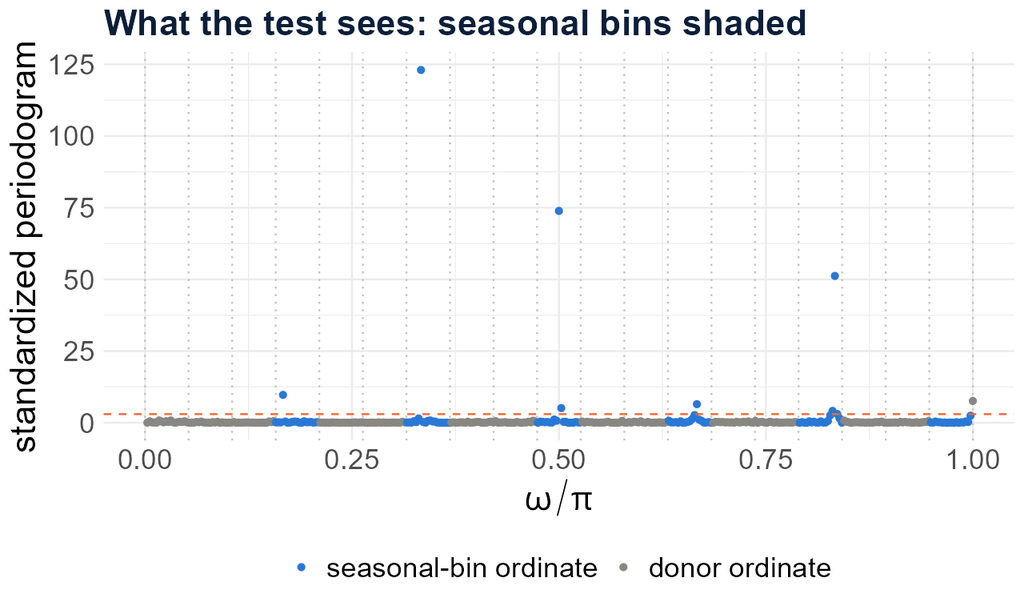

$\hat\Delta$ on UNRATENSA122.2

5% critical value2.19

$M$ bins · whitener19 · $d=1$, AR(2)

verdictreject: seasonal

## Adjustment as the logical conjugate

Deeper Dive · not assessable

Most shops run a test from one tradition and a filter from another, so the filter removes an object the test never measured. The requirement here: **the adjustment removes exactly the excess the test detects**, so re-running the test on the output fails to reject *by construction*. **Stochastic spectral imputation** (SSI), in three moves:

1. **Setup.** DFT the whitened series. Seasonal-bin ordinates are the **targets**; quiet ordinates below a chosen quantile of the non-seasonal floor are the **donors**.
2. **Impute.** Reset each target’s *magnitude* to a randomly drawn donor’s level, keeping the phase — filled from the noise floor, not set to zero, so no spectral hole.
3. **Finalize.** Enforce conjugate symmetry, invert the DFT, recolour through the whitener, restore the levels.

```r
adj_ssi <- seas_adjust(unratensa, phase_rule = "zero",
                       target_set = "bins", seed = 6376)
ssi_nsa <- adjusted(adj_ssi)     # classic SSI
seas_test(ssi_nsa)               # the same test, on the output
```

$\hat\Delta$ after adjustment−2.72

$p$0.877 · fail to reject

first 12 monthsleft unadjusted

**One honest line.** The package’s *default* branch is a different, experimental object: on a series the test classifies as a broad “band” it divides by an estimated gain and imputes nothing — and on UNRATENSA its own post-test rejects ($p\approx 3\times10^{-10}$). The “by construction” claim attaches to the classic call above.

## SSI on UNRATENSA

Deeper Dive · not assessable Classic SSI on UNRATENSA, 1960–2019, replayed from precomputed freqseas draws. Press **Adjust**.

[interactive chart not shown]

## Epilogue: residual seasonality

Residual Seasonality in Core Consumer Price InflationFederal Reserve Board · 2014

"The Phrase of the Day is 'Residual Seasonality'"Wall Street Journal · 2015

U.S. says probe found problem in seasonal adjustment of GDP dataReuters · 2016

Residual Seasonality in GDP Growth Remains after Latest BEA ImprovementsCleveland Fed · 2019

Assessing residual seasonality in published outputsUK Office for National Statistics · 2025

Residual Seasonality in Some Components of PCE InflationCleveland Fed · 2026

Back to the series Module 4 handed us. Its ARMA(1,2) on the published UNRATE showed **serial correlation** at the seasonal lags — a verdict on that fit. The series it was fitted to is the output of an adjustment procedure, so the course’s name for that leftover is **residual seasonality**: the procedure’s own serial correlation, showing up in the data it published. The seasonal ARMA terms of ARIMA$(1,1,2)(1,0,1)_{12}$ are what absorbed it.

**The sign says which way.** $\hat\rho_{12}=-0.145$ and its echoes ($-0.125$, $-0.130$) are *negative*. Under a non-seasonal ARMA that is consistent with the published series carrying **too little** variation at the seasonal frequencies — a seasonal **deficit**, the signature of an adjustment that removed slightly more than the seasonal component. A dip, not a peak.

**Two honest limits.** This is *consistent with* an adjustment-side explanation, not a claim about how the BLS runs its procedure. And the numbers do not establish *why* the dip is there.

## Epilogue: before and after, on the published UNRATE

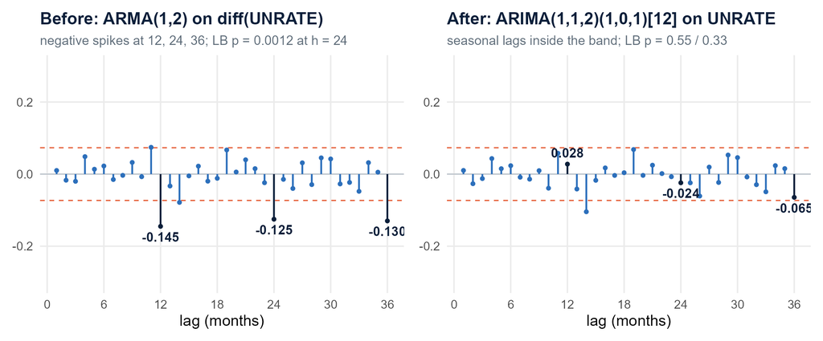

Same series, two fits. The left picture asked Module 4’s question; the right one answers it — seasonal band on, seasonal lags inside the band, Ljung-Box passing at both horizons. When someone asks what residual diagnostics are *for*, hand them this pair.

Deeper Dive · not assessable The frequency domain agrees (notes §5.9.6): on the published series all six seasonal bins sit below their neighbours, ratio 0.75 — on the raw series the ratio is 18.4 — and $\hat\Delta=0.44$, $p=0.23$, fails to reject, because the test is one-sided for *excess*.

## The master equation, fully lit

$$y_t=\alpha+\delta t+\sum_{j=1}^{p}\phi_j y_{t-j}+\sum_{l=1}^{q}\theta_l\epsilon_{t-l}+\epsilon_t$$

— and the seasonal block, written out, is the same structure at lag $s$, multiplied in:

$$\Phi_p(L)\,\Phi_P(L^s)\,(1-L)^d(1-L^s)^D\,y_t=\Theta_q(L)\,\Theta_Q(L^s)\,\epsilon_t$$

| Knob | Module | State |
| --- | --- | --- |
| $\alpha$, $\delta t$ — level and trend | L1, L2 | on |
| $\phi_j$, $\theta_l$ — the base band | L3, L4 | on |
| $(1-L)^d$ — differencing at the base frequency | L2 | on |
| $\Phi_P(L^s)$, $\Theta_Q(L^s)$, $(1-L^s)^D$ — the seasonal band | **L5** | **on** |
| $\epsilon_t$ | L1 | on |

The fitting toolkit built since Module 1 is complete. From here on, every module is about what you *do* with a fitted model, or about lifting it to several variables, or about letting the variance have a master equation of its own.

## Key takeaways

1. **Residuals should behave like innovations.** $e_t$ versus $\epsilon_t$ is the whole foundation of diagnostics. Ljung-Box is the omnibus check: $Q(h)\stackrel{a}{\sim}\chi^2_{h-\text{fitdf}}$, $h=10$ and $h=24$ on monthly data, fitdf set honestly, and a large $p$-value is good news.
2. **Serial correlation is the model’s, not the data’s.** The data has *autocorrelation*. A fitted model earns the verdict *serial correlation*. An adjustment procedure that leaves seasonal autocorrelation in a published series earns *residual seasonality*.
3. **Seasonality is a line you draw.** Four traditions, none nesting the others; whatever lands inside your definition is seasonal by construction. The one safe non-example: monthly sampling alone makes nothing seasonal.
4. **Three paths, and when each applies.** Deterministic → dummies (on UNRATENSA: fixed part absorbed, drifting part left). Stochastic → SARIMA (winner $(1,1,2)(0,1,1)_{12}$, by diagnostics and interior coefficients, because IC cannot compare across differencing orders). “Gone, not modeled” → adjustment (one X-13 call reproduces the published series). And $D$ is a commitment the data push back on from both sides.
5. **The Module 6 handoff:** ARIMA$(1,1,2)(1,0,1)_{12}$ on the *published, adjusted* UNRATE — diagnostic-clean at both horizons, its seasonal ARMA terms absorbing the residual seasonality the adjustment left behind.

## Next time: forecasting

> Module 5 hands Module 6 a **diagnostic-clean univariate model** — the ARIMA$(1,1,2)(1,0,1)_{12}$ on UNRATE that passed Ljung-Box at both horizons.

You have a model. You have checked it. Now the question is what you use it for.

- **Forecasting**: the recursive computation of $\hat y_{t+h\mid t}$ — point, interval, density.
- **Forecast uncertainty**: why the interval grows with the horizon, built from the $\sigma^2$ we have tracked since Module 1.
- **Train/test splits for time series**: random splits are wrong; rolling windows are right.
- **The workflow**: split → fit on the training window → forecast → evaluate on the test window. Today was fit + check. Modules 6 and 7 add the rest.

A forecast is a conditional mean plus honest uncertainty; classical ARMA gives you both.